# week14-_Part 1 Dimensionality Reduction using PCA AND part 2 Feature Selection

Silvia Wakasa Barasa

7/16/2021

```r
library(knitr)
knitr::opts_chunk$set(echo = TRUE,eval=TRUE)
```

# **PROBLEM DEFINITION**

## **a) Specifying the Question**

reducing your dataset to a low dimensional dataset using the PCA

## **b) Defining the metrics for success**

This section of the project entails reducing your dataset to a low dimensional dataset using the PCA. You will be required to perform your analysis and provide insights gained from your analysis.

## **c) Understanding the context**

You are a Data analyst at Carrefour Kenya and are currently undertaking a project that will inform the marketing department on the most relevant marketing strategies that will result in the highest no. of sales (total price including tax). Your project has been divided into four parts where you’ll explore a recent marketing dataset by performing various unsupervised learning techniques and later providing recommendations based on your insights.

## **d) Recording the Experimental Design**

1. Define the question, the metric for success, the context, experimental design taken.
2. Read and explore the given dataset.
3. reducing your dataset to a low dimensional dataset using the PCA

## **e) Relevance of the data**

The data used for this project will inform the marketing department on the most relevant marketing strategies that will result in the highest no. of sales (total price including tax)

[http://bit.ly/CarreFourDataset]

## **Loading and checking data**

```r
sales <- read.csv("C:/Users/Silvia/Documents/R module3 Core/week3/Supermarket_Dataset_1 - Sales Data.csv",stringsAsFactors = T)
head(sales)
```

```
##    Invoice.ID Branch Customer.type Gender           Product.line Unit.price
## 1 750-67-8428      A        Member Female      Health and beauty      74.69
## 2 226-31-3081      C        Normal Female Electronic accessories      15.28
## 3 631-41-3108      A        Normal   Male     Home and lifestyle      46.33
## 4 123-19-1176      A        Member   Male      Health and beauty      58.22
## 5 373-73-7910      A        Normal   Male      Sports and travel      86.31
## 6 699-14-3026      C        Normal   Male Electronic accessories      85.39
##   Quantity     Tax      Date  Time     Payment   cogs gross.margin.percentage
## 1        7 26.1415  1/5/2019 13:08     Ewallet 522.83                4.761905
## 2        5  3.8200  3/8/2019 10:29        Cash  76.40                4.761905
## 3        7 16.2155  3/3/2019 13:23 Credit card 324.31                4.761905
## 4        8 23.2880 1/27/2019 20:33     Ewallet 465.76                4.761905
## 5        7 30.2085  2/8/2019 10:37     Ewallet 604.17                4.761905
## 6        7 29.8865 3/25/2019 18:30     Ewallet 597.73                4.761905
##   gross.income Rating    Total
## 1      26.1415    9.1 548.9715
## 2       3.8200    9.6  80.2200
## 3      16.2155    7.4 340.5255
## 4      23.2880    8.4 489.0480
## 5      30.2085    5.3 634.3785
## 6      29.8865    4.1 627.6165
```

```r
#Checking for size of dataset
dim(sales)
```

```
## [1] 1000   16
```

```r
#Checking for descriptive statistics and Null variables
#And datatypes
summary(sales)
```

```
##        Invoice.ID  Branch  Customer.type    Gender
##  101-17-6199:  1   A:340   Member:501    Female:501
##  101-81-4070:  1   B:332   Normal:499    Male  :499
##  102-06-2002:  1   C:328
##  102-77-2261:  1
##  105-10-6182:  1
##  105-31-1824:  1
##  (Other)    :994
##                  Product.line   Unit.price       Quantity          Tax
##  Electronic accessories:170   Min.   :10.08   Min.   : 1.00   Min.   : 0.5085
##  Fashion accessories   :178   1st Qu.:32.88   1st Qu.: 3.00   1st Qu.: 5.9249
##  Food and beverages    :174   Median :55.23   Median : 5.00   Median :12.0880
##  Health and beauty     :152   Mean   :55.67   Mean   : 5.51   Mean   :15.3794
##  Home and lifestyle    :160   3rd Qu.:77.94   3rd Qu.: 8.00   3rd Qu.:22.4453
##  Sports and travel     :166   Max.   :99.96   Max.   :10.00   Max.   :49.6500
##
##         Date          Time            Payment         cogs
##  2/7/2019 : 20   14:42  :  7   Cash       :344   Min.   : 10.17
##  2/15/2019: 19   19:48  :  7   Credit card:311   1st Qu.:118.50
##  1/8/2019 : 18   17:38  :  6   Ewallet    :345   Median :241.76
##  3/14/2019: 18   10:11  :  5                     Mean   :307.59
##  3/2/2019 : 18   11:40  :  5                     3rd Qu.:448.90
##  1/23/2019: 17   11:51  :  5                     Max.   :993.00
##  (Other)  :890   (Other):965
##  gross.margin.percentage  gross.income         Rating           Total
##  Min.   :4.762           Min.   : 0.5085   Min.   : 4.000   Min.   :  10.68
##  1st Qu.:4.762           1st Qu.: 5.9249   1st Qu.: 5.500   1st Qu.: 124.42
##  Median :4.762           Median :12.0880   Median : 7.000   Median : 253.85
##  Mean   :4.762           Mean   :15.3794   Mean   : 6.973   Mean   : 322.97
##  3rd Qu.:4.762           3rd Qu.:22.4453   3rd Qu.: 8.500   3rd Qu.: 471.35
##  Max.   :4.762           Max.   :49.6500   Max.   :10.000   Max.   :1042.65
##
```

- From the summary, we can deduce the following from the data: 1. We have 1000 records and 16 attributes 2. Out of the 16 attributes, 8 are of data type character 3. We don’t have any null values 4. Looking at the ranges around the summary statistics of our numeric variables, we see that they are measured in different units hence we will need to scale later

```r
head(sales)
```

```
##    Invoice.ID Branch Customer.type Gender           Product.line Unit.price
## 1 750-67-8428      A        Member Female      Health and beauty      74.69
## 2 226-31-3081      C        Normal Female Electronic accessories      15.28
## 3 631-41-3108      A        Normal   Male     Home and lifestyle      46.33
## 4 123-19-1176      A        Member   Male      Health and beauty      58.22
## 5 373-73-7910      A        Normal   Male      Sports and travel      86.31
## 6 699-14-3026      C        Normal   Male Electronic accessories      85.39
##   Quantity     Tax      Date  Time     Payment   cogs gross.margin.percentage
## 1        7 26.1415  1/5/2019 13:08     Ewallet 522.83                4.761905
## 2        5  3.8200  3/8/2019 10:29        Cash  76.40                4.761905
## 3        7 16.2155  3/3/2019 13:23 Credit card 324.31                4.761905
## 4        8 23.2880 1/27/2019 20:33     Ewallet 465.76                4.761905
## 5        7 30.2085  2/8/2019 10:37     Ewallet 604.17                4.761905
## 6        7 29.8865 3/25/2019 18:30     Ewallet 597.73                4.761905
##   gross.income Rating    Total
## 1      26.1415    9.1 548.9715
## 2       3.8200    9.6  80.2200
## 3      16.2155    7.4 340.5255
## 4      23.2880    8.4 489.0480
## 5      30.2085    5.3 634.3785
## 6      29.8865    4.1 627.6165
```

## **Tidying the data**

```r
#Checking to see how many unique values are in each variable
rapply(sales,function(x)length(unique(x)))
```

```
##              Invoice.ID                  Branch           Customer.type
##                    1000                       3                       2
##                  Gender            Product.line              Unit.price
##                       2                       6                     943
##                Quantity                     Tax                    Date
##                      10                     990                      89
##                    Time                 Payment                    cogs
##                     506                       3                     990
## gross.margin.percentage            gross.income                  Rating
##                       1                     990                      61
##                   Total
##                     990
```

- From output, a few columns don’t seem to make sense so we go forward and check them out

```r
#Checking list of unique values for every column
ulst <- lapply(sales, unique)
ulst
```

[output not shown]

[output cut: 800 more lines]

- We don’t have any abnormal entries. So we go ahead to drop the column for InvoiceID since it is only a unique ID for every transaction and will not be necessary for this analysis and the gross margin percentage since it is constant at 4.76 for all transactions.

```r
#Dropping columns
sales <- subset(sales, select = -c(Invoice.ID,gross.margin.percentage))
```

```r
head(sales)
```

```
##   Branch Customer.type Gender           Product.line Unit.price Quantity
## 1      A        Member Female      Health and beauty      74.69        7
## 2      C        Normal Female Electronic accessories      15.28        5
## 3      A        Normal   Male     Home and lifestyle      46.33        7
## 4      A        Member   Male      Health and beauty      58.22        8
## 5      A        Normal   Male      Sports and travel      86.31        7
## 6      C        Normal   Male Electronic accessories      85.39        7
##       Tax      Date  Time     Payment   cogs gross.income Rating    Total
## 1 26.1415  1/5/2019 13:08     Ewallet 522.83      26.1415    9.1 548.9715
## 2  3.8200  3/8/2019 10:29        Cash  76.40       3.8200    9.6  80.2200
## 3 16.2155  3/3/2019 13:23 Credit card 324.31      16.2155    7.4 340.5255
## 4 23.2880 1/27/2019 20:33     Ewallet 465.76      23.2880    8.4 489.0480
## 5 30.2085  2/8/2019 10:37     Ewallet 604.17      30.2085    5.3 634.3785
## 6 29.8865 3/25/2019 18:30     Ewallet 597.73      29.8865    4.1 627.6165
```

## Exploratory Data Analysis

```r
nums <- subset(sales, select = -c(Branch, Customer.type,Gender,Product.line,Date, Time, Payment))
head(nums)
```

```
##   Unit.price Quantity     Tax   cogs gross.income Rating    Total
## 1      74.69        7 26.1415 522.83      26.1415    9.1 548.9715
## 2      15.28        5  3.8200  76.40       3.8200    9.6  80.2200
## 3      46.33        7 16.2155 324.31      16.2155    7.4 340.5255
## 4      58.22        8 23.2880 465.76      23.2880    8.4 489.0480
## 5      86.31        7 30.2085 604.17      30.2085    5.3 634.3785
## 6      85.39        7 29.8865 597.73      29.8865    4.1 627.6165
```

```r
library(tidyr)
```

```r
library(ggplot2)
library(magrittr)
library(dplyr)
library(psych)
# Central tendecy values for numerical variables
describe(nums)
```

```
##              vars    n   mean     sd median trimmed    mad   min     max
## Unit.price      1 1000  55.67  26.49  55.23   55.62  33.37 10.08   99.96
## Quantity        2 1000   5.51   2.92   5.00    5.51   2.97  1.00   10.00
## Tax             3 1000  15.38  11.71  12.09   14.00  11.13  0.51   49.65
## cogs            4 1000 307.59 234.18 241.76  279.91 222.65 10.17  993.00
## gross.income    5 1000  15.38  11.71  12.09   14.00  11.13  0.51   49.65
## Rating          6 1000   6.97   1.72   7.00    6.97   2.22  4.00   10.00
## Total           7 1000 322.97 245.89 253.85  293.91 233.78 10.68 1042.65
##                range skew kurtosis   se
## Unit.price     89.88 0.01    -1.22 0.84
## Quantity        9.00 0.01    -1.22 0.09
## Tax            49.14 0.89    -0.09 0.37
## cogs          982.83 0.89    -0.09 7.41
## gross.income   49.14 0.89    -0.09 0.37
## Rating          6.00 0.01    -1.16 0.05
## Total        1031.97 0.89    -0.09 7.78
```

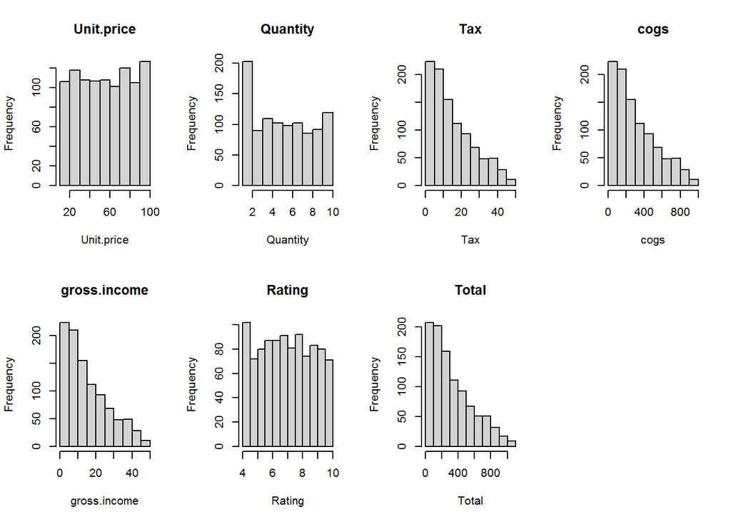

```r
#Distributions of different variables
par( mfrow= c ( 2 , 4 ))
for(i in 1 : length(nums)) {
hist(nums[,i], main= names(nums[i]), xlab = names(nums[i]))
}
```

* Our numerical variables don’t follow a normal distribution. * Amount purchased per unit price seems to vary at all prices though a unit price of 90 to 100 has the highest number of customer entries * Amount purchased seems to decrease with increase in Total and gross income, tax and cogs, with highest frequency levels being where variable values are least.

#### **Checking how different factors affect our target variable “Total”**

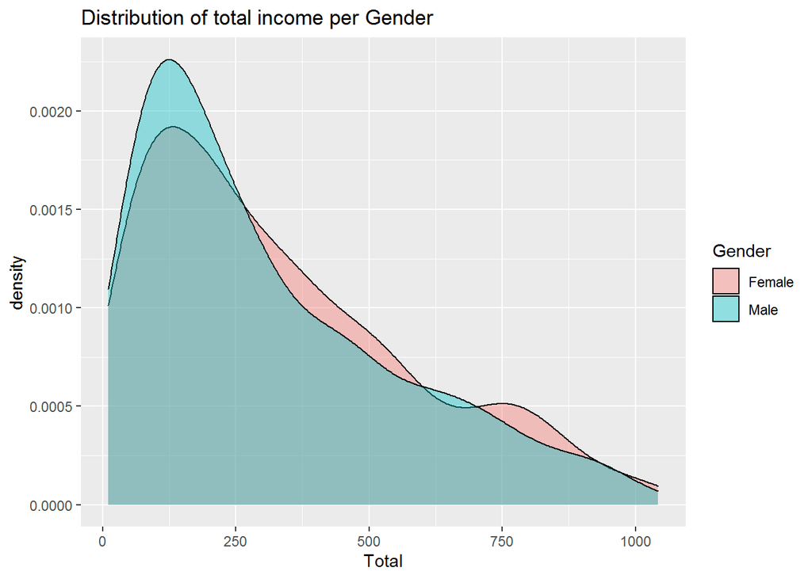

```r
#Distribution of income per Gender
ggplot(sales,
aes(x = Total,
fill = Gender)) +
geom_density(alpha = 0.4) +
labs(title = "Distribution of total income per Gender")
```

* For Totals between 0 and 280 there seem to be more male than female though the frequency of females for totals exceeding 280 seems to surpass male

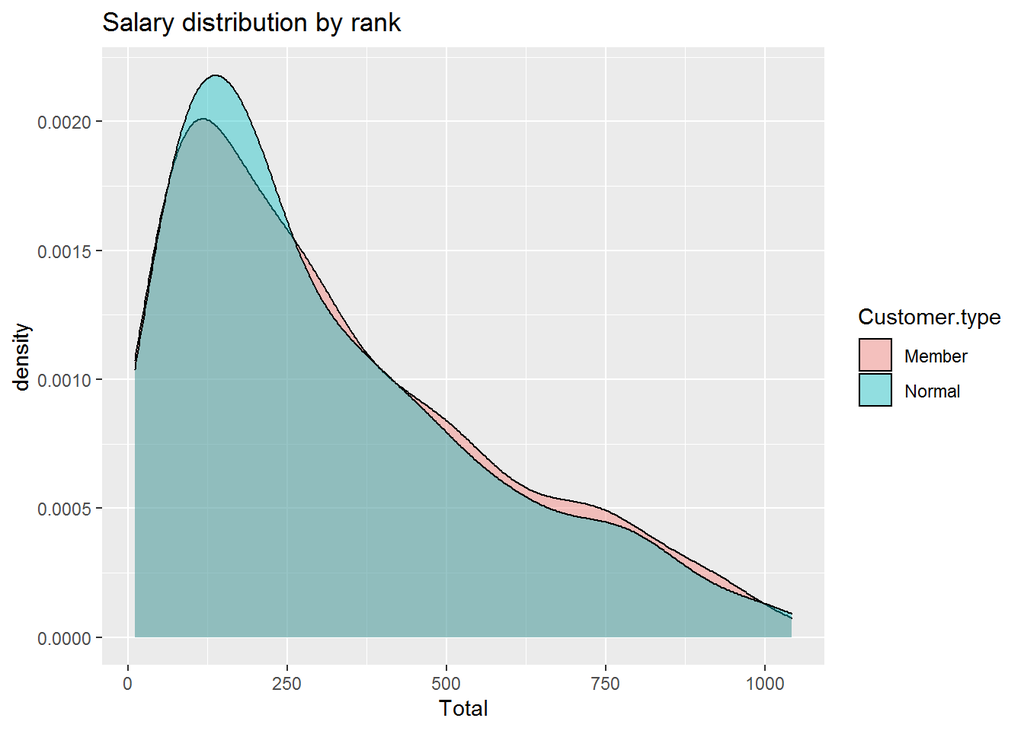

```r
#Salary distribution by rank
ggplot(sales,
aes(x = Total,
fill = Customer.type)) +
geom_density(alpha = 0.4) +
labs(title = "Salary distribution by rank")
```

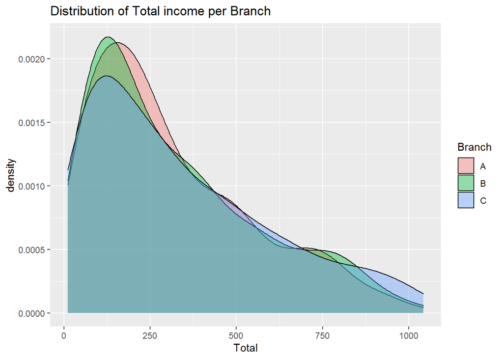

```r
#Distribution of Total income per Branch
ggplot(sales,
aes(x = Total,
fill = Branch)) +
geom_density(alpha = 0.4) +
labs(title = "Distribution of Total income per Branch")
```

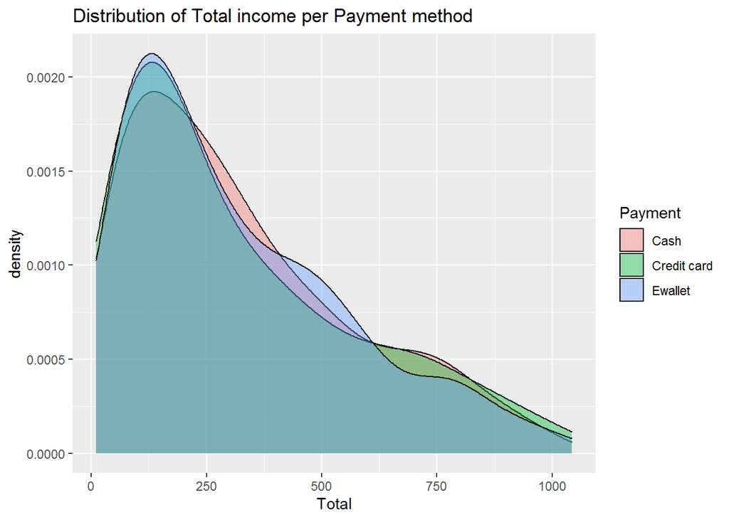

```r
#Distribution of Total per Payment method
ggplot(sales,
aes(x = Total,
fill = Payment)) +
geom_density(alpha = 0.4) +
labs(title = "Distribution of Total income per Payment method")
```

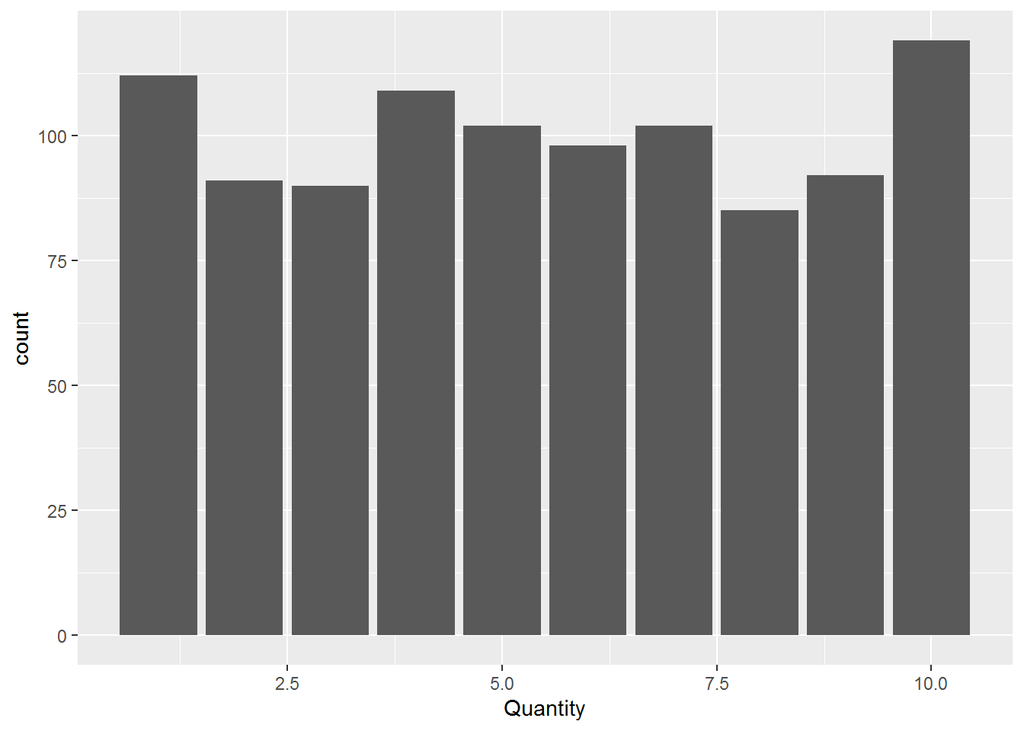

```r
#What quantity was mostly purchased in the store
ggplot(sales, aes(x = Quantity)) +
geom_bar()
```

* * Most people purchased 10items, followed by those who purchased 1 item

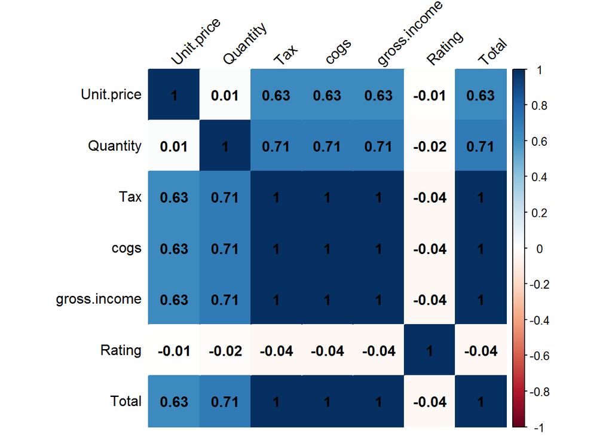

```r
library(corrplot)
#Get the correlation matrix
res = cor(nums)
#Plotting a correlation plot
corrplot(res, method="color",addCoef.col = "black",
tl.col="black", tl.srt=45)
```

* There is perfect correlation between Tax, Cogs and gross income. There is also high correlation between Unit Price and Tax,cogs and gross.income and Total.

## **Dimensionality Reduction**

### **Feature Engineering**

- All variables to be used for dimensionality reduction should be numerical variables, hence we will convert our factor categories to numerics.We will also drop the date and time columns.

```r
#First we will make a copy of our sales dataset for future use
data <- sales
#Dropping columns for date and time
data <- subset(data, select = -c(Date, Time))
head(data)
```

```
##   Branch Customer.type Gender           Product.line Unit.price Quantity
## 1      A        Member Female      Health and beauty      74.69        7
## 2      C        Normal Female Electronic accessories      15.28        5
## 3      A        Normal   Male     Home and lifestyle      46.33        7
## 4      A        Member   Male      Health and beauty      58.22        8
## 5      A        Normal   Male      Sports and travel      86.31        7
## 6      C        Normal   Male Electronic accessories      85.39        7
##       Tax     Payment   cogs gross.income Rating    Total
## 1 26.1415     Ewallet 522.83      26.1415    9.1 548.9715
## 2  3.8200        Cash  76.40       3.8200    9.6  80.2200
## 3 16.2155 Credit card 324.31      16.2155    7.4 340.5255
## 4 23.2880     Ewallet 465.76      23.2880    8.4 489.0480
## 5 30.2085     Ewallet 604.17      30.2085    5.3 634.3785
## 6 29.8865     Ewallet 597.73      29.8865    4.1 627.6165
```

```r
#Converting factor columns to numeric
data$Branch <- as.numeric(data$Branch)
data$Customer.type <- as.numeric(data$Customer.type)
data$Gender <- as.numeric(data$Gender)
data$Product.line <- as.numeric(data$Product.line)
data$Payment <- as.numeric(data$Payment)
data$Quantity <- as.numeric(data$Quantity)
head(data)
```

```
##   Branch Customer.type Gender Product.line Unit.price Quantity     Tax Payment
## 1      1             1      1            4      74.69        7 26.1415       3
## 2      3             2      1            1      15.28        5  3.8200       1
## 3      1             2      2            5      46.33        7 16.2155       2
## 4      1             1      2            4      58.22        8 23.2880       3
## 5      1             2      2            6      86.31        7 30.2085       3
## 6      3             2      2            1      85.39        7 29.8865       3
##     cogs gross.income Rating    Total
## 1 522.83      26.1415    9.1 548.9715
## 2  76.40       3.8200    9.6  80.2200
## 3 324.31      16.2155    7.4 340.5255
## 4 465.76      23.2880    8.4 489.0480
## 5 604.17      30.2085    5.3 634.3785
## 6 597.73      29.8865    4.1 627.6165
```

```r
install.packages("factoextra",dependencies = TRUE,repos = 'http://cran.rstudio.com/')
library(factoextra)
#Performing pca
data.pca <- prcomp(data[,c(1:11)], center = TRUE, scale. = TRUE)
summary(data.pca)
```

```
## Importance of components:
##                           PC1    PC2     PC3     PC4     PC5    PC6     PC7
## Standard deviation     1.9836 1.0631 1.03159 1.00991 0.99289 0.9771 0.96270
## Proportion of Variance 0.3577 0.1027 0.09674 0.09272 0.08962 0.0868 0.08425
## Cumulative Proportion  0.3577 0.4604 0.55719 0.64991 0.73953 0.8263 0.91058
##                            PC8     PC9      PC10      PC11
## Standard deviation     0.94823 0.29062 1.573e-16 3.089e-17
## Proportion of Variance 0.08174 0.00768 0.000e+00 0.000e+00
## Cumulative Proportion  0.99232 1.00000 1.000e+00 1.000e+00
```

```r
str(data.pca)
```

```
## List of 5
##  $ sdev    : num [1:11] 1.984 1.063 1.032 1.01 0.993 ...
##  $ rotation: num [1:11, 1:11] 0.0267 -0.0155 -0.0338 0.0206 0.3273 ...
##   ..- attr(*, "dimnames")=List of 2
##   .. ..$ : chr [1:11] "Branch" "Customer.type" "Gender" "Product.line" ...
##   .. ..$ : chr [1:11] "PC1" "PC2" "PC3" "PC4" ...
##  $ center  : Named num [1:11] 1.99 1.5 1.5 3.45 55.67 ...
##   ..- attr(*, "names")= chr [1:11] "Branch" "Customer.type" "Gender" "Product.line" ...
##  $ scale   : Named num [1:11] 0.818 0.5 0.5 1.715 26.495 ...
##   ..- attr(*, "names")= chr [1:11] "Branch" "Customer.type" "Gender" "Product.line" ...
##  $ x       : num [1:1000, 1:11] 1.79 -2.05 0.11 1.29 2.43 ...
##   ..- attr(*, "dimnames")=List of 2
##   .. ..$ : chr [1:1000] "1" "2" "3" "4" ...
##   .. ..$ : chr [1:11] "PC1" "PC2" "PC3" "PC4" ...
##  - attr(*, "class")= chr "prcomp"
```

- We have obtained 11 principal components. Our first PC, PC1 explains 35.7% Variation, our second, PC2 explains 10.3%. The first 8 PCs gives us a variability proportion of upto 99%.

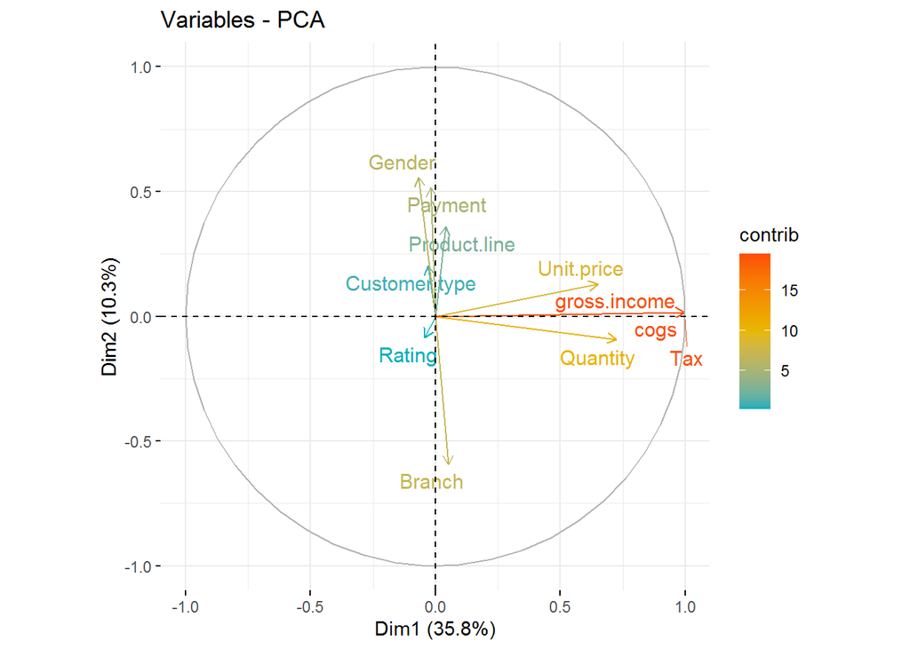

```r
#Graph of variables
fviz_pca_var(data.pca,
col.var = "contrib", # Color by contributions to the PC
gradient.cols = c("#00AFBB", "#E7B800", "#FC4E07"),
repel = TRUE # Avoid text overlapping
)
```

```r
# Eigenvalues
eig.val <- get_eigenvalue(data.pca)
eig.val
```

```
##          eigenvalue variance.percent cumulative.variance.percent
## Dim.1  3.934732e+00     3.577029e+01                    35.77029
## Dim.2  1.130132e+00     1.027393e+01                    46.04423
## Dim.3  1.064187e+00     9.674426e+00                    55.71865
## Dim.4  1.019927e+00     9.272061e+00                    64.99071
## Dim.5  9.858334e-01     8.962122e+00                    73.95283
## Dim.6  9.548085e-01     8.680077e+00                    82.63291
## Dim.7  9.267825e-01     8.425296e+00                    91.05821
## Dim.8  8.991345e-01     8.173950e+00                    99.23216
## Dim.9  8.446266e-02     7.678424e-01                   100.00000
## Dim.10 2.474825e-32     2.249841e-31                   100.00000
## Dim.11 9.542153e-34     8.674684e-33                   100.00000
```

- Since the first 8 Principal Components contribute upto 99.23% of the variance proportion, they can be used for analysis.

## **Feature Selection**

- Using Filter Method Using the filter method, we will check for correlation between variables. We will then remove variables that are highly correlated as that is a sign of redundancy.

```r
library(caret)
#Separating target variable with independent variables
df <- data[-12]
# Calculating the correlation matrix
correlationMatrix <- cor(df)
# Find attributes that are highly correlated
highlyCorrelated <- findCorrelation(correlationMatrix, cutoff= 0.75)
# Highly correlated attributes
highlyCorrelated
```

```
## [1] 7 9
```

```r
names(df[,highlyCorrelated])
```

```
## [1] "Tax"  "cogs"
```

- Tax and Cogs are highly correlated.

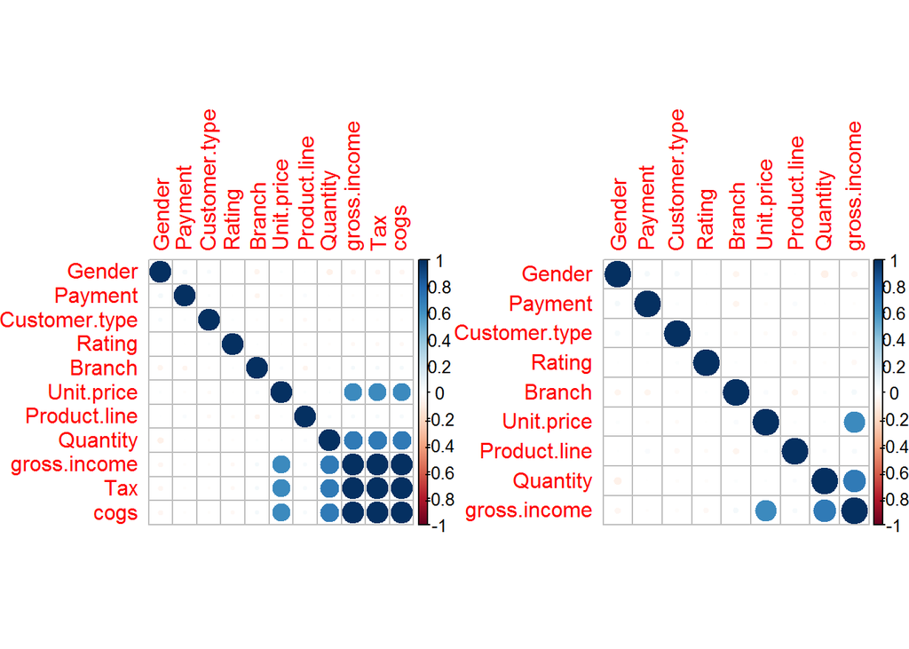

```r
# Removing the highly correlated features
df.feat<-df[-highlyCorrelated]
# Performing a graphical comparison
par(mfrow = c(1, 2))
corrplot(correlationMatrix, order = "hclust")
corrplot(cor(df.feat), order = "hclust")
```

## **Conclusion**

- that the following features will be used for analysis:
- Gender
- Payment
- Customer type
- Rating
- Branch
- Unit price
- Product line
- Quantity
- Gross Income